# Hackaton MOOD summer school 2023

A - tick occurrences GB

Paolo Dalena

2023-05-25

## Download the data

```r
rep = "http://s3.eu-central-1.wasabisys.com/mood/training/"
rds = url(paste0(rep, "ticks_training_set.rds"))
train = readRDS(rds)

dim(train)
```

```
## [1] 14800   125
```

I have 125 variables, I have to perform a variable reduction, of course.

```r
names(train)
```

```
##   [1] "Time_step"
##   [2] "Ticks"
##   [3] "Total"
##   [4] "Density"
##   [5] "Grid_ID"
##   [6] "X"
##   [7] "Y"
##   [8] "Date"
##   [9] "row.id"
##  [10] "bioclim1_chelsa.v2.1_s_19820101_20101231_gb_epsg.27700_v20230207"
##  [11] "bioclim10_chelsa.v2.1_s_19820101_20101231_gb_epsg.27700_v20230207"
##  [12] "bioclim11_chelsa.v2.1_s_19820101_20101231_gb_epsg.27700_v20230207"
##  [13] "bioclim12_chelsa.v2.1_s_19820101_20101231_gb_epsg.27700_v20230207"
##  [14] "bioclim2_chelsa.v2.1_s_19820101_20101231_gb_epsg.27700_v20230207"
##  [15] "bioclim3_chelsa.v2.1_s_19820101_20101231_gb_epsg.27700_v20230207"
```

[output cut: 110 more lines]

## Considerations and plan of analysis

I am a data scientist, I have no idea what information the covariates contain, and I have no knowledge of whether some covariates may be associated with the outcome I want to estimate. Looking at the variable names, however, it seems to me that it is possible that there are redundant variables that contain similar information. It might be interesting to group the variables and eliminate the redundant ones, so as to streamline the analysis from the very beginning. I would then like to apply what has been talked about these days, so I would like to apply the Ensemble ML, perhaps weighing with the weights of the coefficients of the meta learners model the most important variables for each candidate model. I will also try to validate my models by considering a spatial CV, to consider *space*, and I will include in the analyses a temporal variable (e.g., the cosine of months), to consider *time*.

For now I have:

- variable clustering;
- understanding how to consider time in my model;
- defining folds (?) for Spatial CV;
- Train the model;
- building the dataset for testing;
- fit the results.

**But these are just ideas, then will evaluate based on time.**

Note from 5-hours-later-Paolo: this plan was not followed precisely.

## Minor changes in dataset

I will remove the problematic variable **tick_f**:

```r
train <- train[,names(train) != "tick_f"]
```

I will also remove the rows with NAs:

```r
train <- na.omit(train)
```

## Descriptive analysis

Just to have a clearer vision of the dataset.

```r
table(train$Ticks)
```

```
##
##    0    1    2    3    4
## 7192 6894  287   20    4
```

```r
table(train$Ticks==0)
```

```
##
## FALSE  TRUE
##  7205  7192
```

0 and non-0 are perfectly balanced.

```r
range(train$Date)
```

```
## [1] "2014-04-15" "2021-12-15"
```

```r
unique(train$Date)
```

```
##  [1] "2016-09-15" "2014-08-15" "2021-06-15" "2017-06-15" "2016-06-15"
##  [6] "2017-10-15" "2018-04-15" "2017-07-15" "2018-07-15" "2018-02-15"
## [11] "2016-08-15" "2015-02-15" "2016-04-15" "2018-10-15" "2016-07-15"
## [16] "2018-01-15" "2016-11-15" "2015-11-15" "2019-06-15" "2019-04-15"
## [21] "2020-06-15" "2018-08-15" "2014-10-15" "2020-11-15" "2019-08-15"
## [26] "2017-05-15" "2017-09-15" "2014-09-15" "2019-03-15" "2018-05-15"
## [31] "2014-06-15" "2021-04-15" "2017-04-15" "2016-05-15" "2017-03-15"
## [36] "2018-06-15" "2015-04-15" "2021-10-15" "2019-05-15" "2016-10-15"
## [41] "2017-08-15" "2015-09-15" "2021-08-15" "2019-07-15" "2015-03-15"
## [46] "2015-06-15" "2021-05-15" "2021-07-15" "2021-09-15" "2018-09-15"
## [51] "2020-07-15" "2015-10-15" "2020-02-15" "2019-09-15" "2018-11-15"
## [56] "2019-10-15" "2020-10-15" "2016-12-15" "2020-05-15" "2016-03-15"
## [61] "2021-03-15" "2017-02-15" "2020-09-15" "2020-08-15" "2018-12-15"
## [66] "2020-03-15" "2019-12-15" "2019-11-15" "2020-12-15" "2015-07-15"
## [71] "2015-12-15" "2014-11-15" "2015-05-15" "2017-11-15" "2015-08-15"
## [76] "2014-04-15" "2014-07-15" "2018-03-15" "2016-02-15" "2014-05-15"
## [81] "2019-02-15" "2021-12-15" "2021-11-15" "2020-01-15" "2019-01-15"
## [86] "2016-01-15" "2014-12-15" "2017-12-15" "2020-04-15" "2021-01-15"
## [91] "2017-01-15" "2015-01-15" "2021-02-15"
```

```r
length(unique(train$Date))
```

```
## [1] 93
```

14800 observations from ONLY 93 unique dates! Given this result, it probably does not make sense to spend too much time creating a variable that considers the time trend in the dataset. It may make sense to consider time only to group data, considering seasons, for example, or months Of course, by doing so I lose information about the actual consequentiality of time, but it is probably not a huge loss.

Anyway, I will create a grouping variable and a variable that considers the passing of time so that everything is taken into account.

Grouping variable (months). I will extract the month from the date (that is a fake day, but the month and the year is reliable, as in the variable *Time_step*). For the passing of time I already have the cosmonth variable in the dataset.

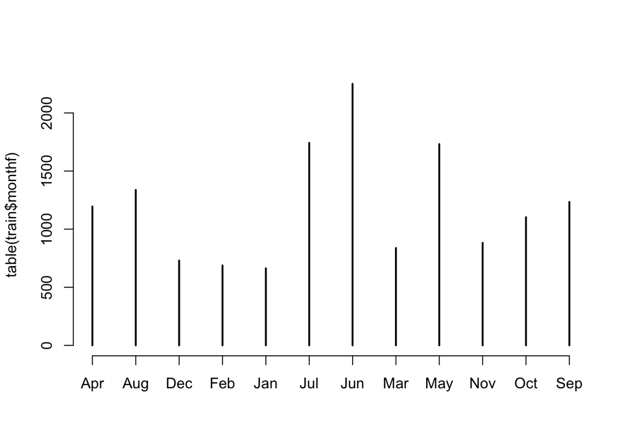

```r
train$monthf <- factor(format(train$Date, "%b"))
plot(table(train$monthf))
```

```r
table(round(train$cosmonth,2))
```

```
##
##    -1 -0.87  -0.5     0   0.5  0.87     1
##  2251  3475  2533  2072  1791  1545   730
```

Even if this variable doesn’t seem to be so informative, since we have only 7 unique values.

## Variable clustering and a-priori variable selection

I will perform a variable clustering considering only the numeric covariates.

```r
library(Hmisc)
str(train)
```

```
## 'data.frame':    14397 obs. of  125 variables:
##  $ Time_step                                                                             : chr  "09/2016" "08/2014" "06/2021" "09/2016" ...
##  $ Ticks                                                                                 : int  1 1 1 1 2 1 1 1 1 1 ...
##  $ Total                                                                                 : int  11 22 2 64 8 132 2 7 4 56 ...
##  $ Density                                                                               : num  0.0909 0.0455 0.5 0.0156 0.25 ...
##  $ Grid_ID                                                                               : int  381937 115331 262225 269933 314011 203652 106897 234950 91508 170014 ...
##  $ X                                                                                     : num  436500 530500 424500 432500 410500 ...
##  $ Y                                                                                     : num  545500 164500 374500 385500 448500 ...
##  $ Date                                                                                  : Date, format: "2016-09-15" "2014-08-15" ...
##  $ row.id                                                                                : int  263929 128875 1223163 260432 442263 202760 465605 472828 558594 402183 ...
##  $ bioclim1_chelsa.v2.1_s_19820101_20101231_gb_epsg.27700_v20230207                      : num  2824 2836 2823 2822 2822 ...
##  $ bioclim10_chelsa.v2.1_s_19820101_20101231_gb_epsg.27700_v20230207                     : num  2878 2897 2881 2880 2879 ...
##  $ bioclim11_chelsa.v2.1_s_19820101_20101231_gb_epsg.27700_v20230207                     : num  2775 2780 2769 2769 2771 ...
##  $ bioclim12_chelsa.v2.1_s_19820101_20101231_gb_epsg.27700_v20230207                     : num  7092 6709 9939 9657 10765 ...
##  $ bioclim2_chelsa.v2.1_s_19820101_20101231_gb_epsg.27700_v20230207                      : num  56 69 62 63 61 29 70 68 67 52 ...
```

[output cut: 88 more lines]

```r
# just to check
res <- numeric(0)
for(i in 1:124){
  res[i] <- is.numeric(train[,i])
}
res[10:124] == 1
```

```
##   [1] TRUE TRUE TRUE TRUE TRUE TRUE TRUE TRUE TRUE TRUE TRUE TRUE TRUE TRUE TRUE
##  [16] TRUE TRUE TRUE TRUE TRUE TRUE TRUE TRUE TRUE TRUE TRUE TRUE TRUE TRUE TRUE
##  [31] TRUE TRUE TRUE TRUE TRUE TRUE TRUE TRUE TRUE TRUE TRUE TRUE TRUE TRUE TRUE
##  [46] TRUE TRUE TRUE TRUE TRUE TRUE TRUE TRUE TRUE TRUE TRUE TRUE TRUE TRUE TRUE
##  [61] TRUE TRUE TRUE TRUE TRUE TRUE TRUE TRUE TRUE TRUE TRUE TRUE TRUE TRUE TRUE
##  [76] TRUE TRUE TRUE TRUE TRUE TRUE TRUE TRUE TRUE TRUE TRUE TRUE TRUE TRUE TRUE
##  [91] TRUE TRUE TRUE TRUE TRUE TRUE TRUE TRUE TRUE TRUE TRUE TRUE TRUE TRUE TRUE
## [106] TRUE TRUE TRUE TRUE TRUE TRUE TRUE TRUE TRUE TRUE
```

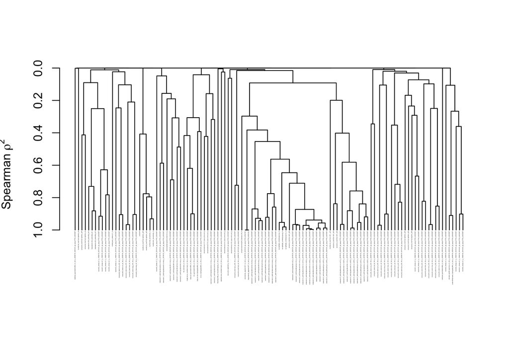

```r
vcl <- varclus(as.matrix(train[,10:124]), similarity = "spear", type = "data.matrix")
plot(vcl, cex = 0.1, hang = -1)
```

As expected there are many variables that are merged in the same cluster at a lower level => they contain a similar information => I should perform a variable selection.

In order to exclude redundant variables, I could select the variables that contain ‘original’ information. But how? Let’s check the correlations:

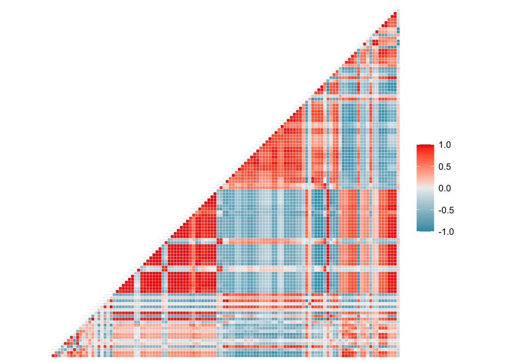

```r
library(car)
library(pROC)
GGally::ggcorr(cor(train[10:124]), geom = "tile", cex = 0.1)
```

Let’s remove some variables considering correlation coefficients:

```r
to_remove <- caret::findCorrelation(cor(train[,10:124]), cutoff = .6, names = T)
to_remove
```

```
##  [1] "bioclim10_chelsa.v2.1_s_19820101_20101231_gb_epsg.27700_v20230207"
##  [2] "bioclim4_chelsa.v2.1_s_19820101_20101231_gb_epsg.27700_v20230207"
##  [3] "bioclim5_chelsa.v2.1_s_19820101_20101231_gb_epsg.27700_v20230207"
##  [4] "bioclim6_chelsa.v2.1_s_19820101_20101231_gb_epsg.27700_v20230207"
##  [5] "bioclim7_chelsa.v2.1_s_19820101_20101231_gb_epsg.27700_v20230207"
##  [6] "seasonal.s1_earth.big.data.fall.vv.amp_s_20190101_20201231_gb_epsg.27700_v20230207"
##  [7] "seasonal.s1_earth.big.data.fall.vv.coh12_s_20190101_20201231_gb_epsg.27700_v20230207"
##  [8] "seasonal.s1_earth.big.data.fall.vv.coh24_s_20190101_20201231_gb_epsg.27700_v20230207"
##  [9] "seasonal.s1_earth.big.data.fall.vv.coh36_s_20190101_20201231_gb_epsg.27700_v20230207"
## [10] "seasonal.s1_earth.big.data.fall.vv.coh48_s_20190101_20201231_gb_epsg.27700_v20230207"
## [11] "seasonal.s1_earth.big.data.fall.vv.rho_s_20190101_20201231_gb_epsg.27700_v20230207"
## [12] "seasonal.s1_earth.big.data.fall.vv.tau_s_20190101_20201231_gb_epsg.27700_v20230207"
## [13] "seasonal.s1_earth.big.data.spring.vh.amp_s_20190101_20201231_gb_epsg.27700_v20230207"
## [14] "seasonal.s1_earth.big.data.spring.vv.amp_s_20190101_20201231_gb_epsg.27700_v20230207"
## [15] "seasonal.s1_earth.big.data.spring.vv.coh12_s_20190101_20201231_gb_epsg.27700_v20230207"
```

[output cut: 56 more lines]

```r
train.sub <- train[!colnames(train) %in% to_remove]
dim(train.sub)
```

```
## [1] 14397    54
```

Let’s run the variable clustering again:

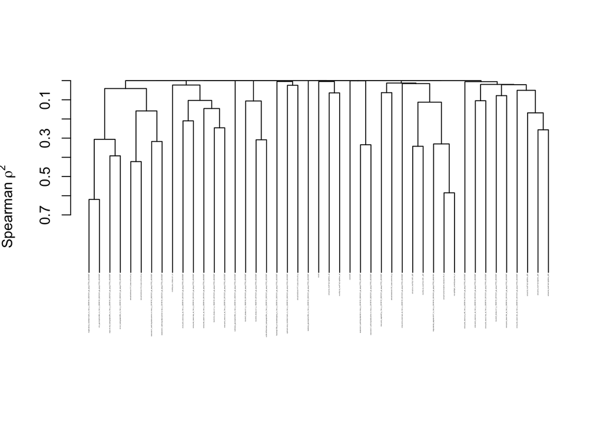

```r
vcl <- varclus(as.matrix(train.sub[,10:ncol(train.sub)-1]), similarity = "spear", type = "data.matrix")
plot(vcl, cex = 0.1, hang = -.1)
```

## Variable importance considering Boruta algorithm

```r
library(Boruta)
# boruta <- Boruta(Ticks ~ ., data = train.sub[,-c(1,3,5:9)], doTrace = 2, maxRuns = 100)
#save(boruta, file = "boruta_pd.rdata")
load("boruta_pd.rdata")
print(boruta)
```

```
## Boruta performed 99 iterations in 59.9225 mins.
##  40 attributes confirmed important: annual.evi_mod13q1.v061_p05,
## annual.human.footprint_hpressure.50_m,
## annual.landcover.311_lucas.corine.eml_p,
## annual.landcover.312_lucas.corine.eml_p,
## annual.landcover.321_lucas.corine.eml_p and 35 more;
##  3 attributes confirmed unimportant:
## annual.landcover.411_lucas.corine.eml_p,
## floodmap.500y_jrc.hazardmapping_m_1km_s_20000101_20201231_gb_epsg.27700_v20230207,
## snow.prob_esacci.jul_p.90_1km_s_20000101_20121231_gb_epsg.27700_v20230207;
##  3 tentative attributes left: monthly.lst_mod11a2.nighttime_sd,
## snow.prob_esacci.apr_sd_1km_s_20000101_20121231_gb_epsg.27700_v20230207,
## snow.prob_esacci.may_sd_1km_s_20000101_20121231_gb_epsg.27700_v20230207;
```

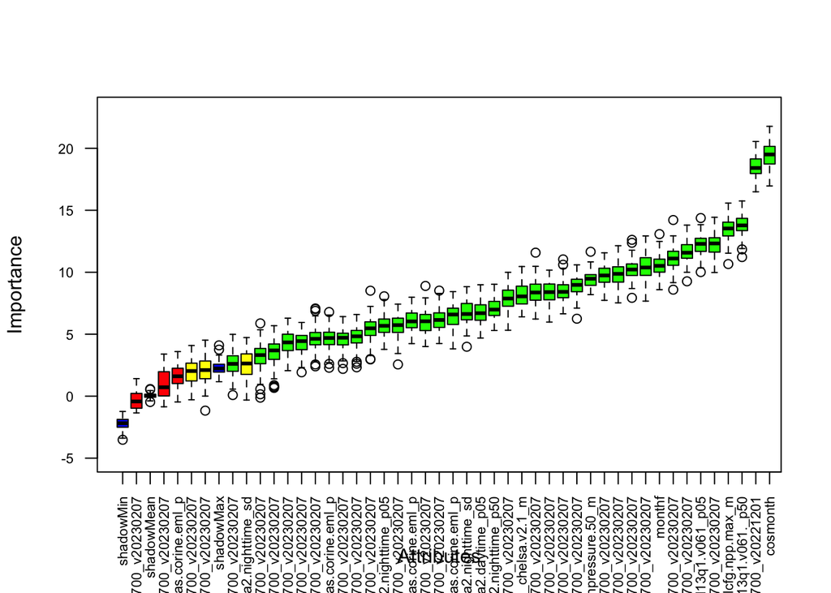

```r
plot(boruta, las = 2, cex.axis = 0.7, ylim = c(-5,23), xlim = c(1,47))
```

```r
attStats(boruta)[-1,]%>%
    dplyr::arrange(desc(meanImp)) %>%
    knitr::kable(booktabs = T)%>%
    kable_styling()
```

|  | meanImp | medianImp | minImp | maxImp | normHits | decision |
| --- | --- | --- | --- | --- | --- | --- |
| cosmonth | 19.4605472 | 19.5020741 | 16.9614299 | 21.773875 | 1.0000000 | Confirmed |
| dogs.density_aegerter.2017_m_1km_s_20160101_20181231_gb_epsg.27700_v20221201 | 18.5177187 | 18.4138553 | 16.4916412 | 20.551747 | 1.0000000 | Confirmed |
| monthly.evi_mod13q1.v061._p50 | 13.8313449 | 13.7811474 | 11.2240720 | 15.750286 | 1.0000000 | Confirmed |
| vis.nightlight_vcmslcfg.npp.max_m | 13.4310982 | 13.5324718 | 10.6615245 | 15.581874 | 1.0000000 | Confirmed |
| bioclim9_chelsa.v2.1_s_19820101_20101231_gb_epsg.27700_v20230207 | 12.2556353 | 12.3227513 | 9.9768109 | 14.437314 | 1.0000000 | Confirmed |
| annual.evi_mod13q1.v061_p05 | 12.1915601 | 12.2926043 | 10.0125970 | 14.374472 | 1.0000000 | Confirmed |
| bioclim12_chelsa.v2.1_s_19820101_20101231_gb_epsg.27700_v20230207 | 11.6628480 | 11.5740226 | 9.2676476 | 13.802810 | 1.0000000 | Confirmed |
| seasonal.s1_earth.big.data.fall.vv.rmse_s_20190101_20201231_gb_epsg.27700_v20230207 | 11.1373302 | 11.1075482 | 8.5930029 | 14.213288 | 1.0000000 | Confirmed |
| monthf | 10.5366873 | 10.5161426 | 8.5941389 | 13.077462 | 1.0000000 | Confirmed |
| seasonal.s1_earth.big.data.winter.vv.rmse_s_20190101_20201231_gb_epsg.27700_v20230207 | 10.4654880 | 10.3807356 | 7.6701690 | 12.930772 | 1.0000000 | Confirmed |
| bioclim8_chelsa.v2.1_s_19820101_20101231_gb_epsg.27700_v20230207 | 10.1901524 | 10.2173678 | 7.9344756 | 12.614382 | 1.0000000 | Confirmed |
| seasonal.s1_earth.big.data.summer.vv.rmse_s_20190101_20201231_gb_epsg.27700_v20230207 | 9.8371573 | 9.8706789 | 7.5287185 | 12.142592 | 1.0000000 | Confirmed |
| outlet.diff.dw.basin_hydrography90m_m_1km_s_20000101_20201231_gb_epsg.27700_v20230207 | 9.7709217 | 9.7416308 | 7.7312317 | 11.565800 | 1.0000000 | Confirmed |
| annual.human.footprint_hpressure.50_m | 9.4083592 | 9.4755330 | 8.1923530 | 11.654921 | 1.0000000 | Confirmed |
| height.above_meritdem.hydro_m_1km_s_20000101_20201231_gb_epsg.27700_v20230207 | 8.9146097 | 8.9779461 | 6.2506147 | 10.598083 | 1.0000000 | Confirmed |
| bioclim3_chelsa.v2.1_s_19820101_20101231_gb_epsg.27700_v20230207 | 8.5118380 | 8.4171122 | 6.6454141 | 11.037510 | 1.0000000 | Confirmed |
| vrm_geomorphon90m_m_1km_s_20000101_20201231_gb_epsg.27700_v20230207 | 8.4045246 | 8.3967567 | 5.9785140 | 10.168271 | 1.0000000 | Confirmed |
| seasonal.s1_earth.big.data.summer.vv.tau_s_20190101_20201231_gb_epsg.27700_v20230207 | 8.3870636 | 8.3655362 | 6.2240706 | 11.581074 | 1.0000000 | Confirmed |
| monthly.prec_chelsa.v2.1_m | 8.1525481 | 8.0535964 | 6.4041217 | 10.461629 | 1.0000000 | Confirmed |
| deer.prob_osgbirall3_p_1km_s_20180101_20201231_gb_epsg.27700_v20230207 | 7.9313578 | 7.8776402 | 5.3200879 | 9.996830 | 1.0000000 | Confirmed |
| annual.lst_mod11a2.nighttime_p50 | 7.0482357 | 6.9858012 | 5.2996285 | 9.029700 | 1.0000000 | Confirmed |
| annual.lst_mod11a2.nighttime_sd | 6.7564464 | 6.6293779 | 3.9885650 | 8.833438 | 1.0000000 | Confirmed |
| annual.lst_mod11a2.daytime_p05 | 6.7375757 | 6.6956558 | 4.6894568 | 8.989491 | 1.0000000 | Confirmed |
| annual.landcover.311_lucas.corine.eml_p | 6.4848323 | 6.5885993 | 3.8202064 | 8.435440 | 1.0000000 | Confirmed |
| sti.ovr_hydrography90m_m_1km_s_20000101_20201231_gb_epsg.27700_v20230207 | 6.1982294 | 6.1496628 | 4.2455599 | 8.518053 | 1.0000000 | Confirmed |
| annual.landcover.321_lucas.corine.eml_p | 6.0877105 | 6.0317498 | 4.2392444 | 7.983013 | 1.0000000 | Confirmed |
| northness_geomorphon90m_m_1km_s_20000101_20201231_gb_epsg.27700_v20230207 | 6.0190224 | 6.0417076 | 4.0026653 | 8.895876 | 1.0000000 | Confirmed |
| annual.lst_mod11a2.nighttime_p05 | 5.7046684 | 5.6790127 | 3.7775420 | 8.061870 | 1.0000000 | Confirmed |
| snow.prob_esacci.nov_sd_1km_s_20000101_20121231_gb_epsg.27700_v20230207 | 5.6706431 | 5.7334543 | 2.5605431 | 7.425294 | 0.9898990 | Confirmed |
| eastness_geomorphon90m_m_1km_s_20000101_20201231_gb_epsg.27700_v20230207 | 5.4271404 | 5.4750672 | 2.9654605 | 8.511727 | 1.0000000 | Confirmed |
| slope.elv.dw_hydrography90m_m_1km_s_20000101_20201231_gb_epsg.27700_v20230207 | 4.7512917 | 4.8304726 | 2.3278689 | 6.588888 | 1.0000000 | Confirmed |
| snow.prob_esacci.oct_sd_1km_s_20000101_20121231_gb_epsg.27700_v20230207 | 4.6412371 | 4.7172342 | 2.2011848 | 6.422234 | 0.9898990 | Confirmed |
| snow.prob_esacci.feb_sd_1km_s_20000101_20121231_gb_epsg.27700_v20230207 | 4.6255830 | 4.6278901 | 2.4069167 | 7.077947 | 0.9696970 | Confirmed |
| annual.landcover.312_lucas.corine.eml_p | 4.5974038 | 4.6933653 | 2.2942647 | 6.789118 | 0.9898990 | Confirmed |
| snow.prob_esacci.dec_sd_1km_s_20000101_20121231_gb_epsg.27700_v20230207 | 4.3109176 | 4.3382782 | 2.0579192 | 6.293455 | 0.9696970 | Confirmed |
| snow.prob_esacci.aug_sd_1km_s_20000101_20121231_gb_epsg.27700_v20230207 | 4.2921295 | 4.4402915 | 1.9277820 | 5.949887 | 0.9696970 | Confirmed |
| snow.prob_esacci.sep_sd_1km_s_20000101_20121231_gb_epsg.27700_v20230207 | 3.5916956 | 3.6909787 | 0.6675011 | 5.685241 | 0.8686869 | Confirmed |
| snow.prob_esacci.jun_sd_1km_s_20000101_20121231_gb_epsg.27700_v20230207 | 3.2137531 | 3.3184921 | -0.1185921 | 5.875108 | 0.7979798 | Confirmed |
| upstream.area_meritdem.hydro_m_1km_s_20000101_20201231_gb_epsg.27700_v20230207 | 2.6352412 | 2.6069840 | 0.0913842 | 4.987851 | 0.6868687 | Confirmed |
| monthly.lst_mod11a2.nighttime_sd | 2.5176979 | 2.6358934 | -0.3110707 | 4.730067 | 0.6060606 | Tentative |
| snow.prob_esacci.apr_sd_1km_s_20000101_20121231_gb_epsg.27700_v20230207 | 2.0801485 | 2.1053467 | -1.1654313 | 4.522237 | 0.4949495 | Tentative |
| snow.prob_esacci.may_sd_1km_s_20000101_20121231_gb_epsg.27700_v20230207 | 1.9299835 | 2.0301384 | -0.2920228 | 4.087905 | 0.4747475 | Tentative |
| annual.landcover.411_lucas.corine.eml_p | 1.6224942 | 1.6063753 | -0.4656641 | 3.598278 | 0.2727273 | Rejected |
| snow.prob_esacci.jul_p.90_1km_s_20000101_20121231_gb_epsg.27700_v20230207 | 0.9849649 | 0.7172369 | -0.8556788 | 3.394717 | 0.0303030 | Rejected |
| floodmap.500y_jrc.hazardmapping_m_1km_s_20000101_20201231_gb_epsg.27700_v20230207 | -0.2970632 | -0.4223014 | -1.3511128 | 1.417326 | 0.0000000 | Rejected |

I will take a threshold of 10 for the mean importance, so I will keep the following variables:

```r
res <- attStats(boruta)[-1,]%>%
    dplyr::arrange(desc(meanImp))
impvars <- rownames(res[1:11,])
impvars
```

```
##  [1] "cosmonth"
##  [2] "dogs.density_aegerter.2017_m_1km_s_20160101_20181231_gb_epsg.27700_v20221201"
##  [3] "monthly.evi_mod13q1.v061._p50"
##  [4] "vis.nightlight_vcmslcfg.npp.max_m"
##  [5] "bioclim9_chelsa.v2.1_s_19820101_20101231_gb_epsg.27700_v20230207"
##  [6] "annual.evi_mod13q1.v061_p05"
##  [7] "bioclim12_chelsa.v2.1_s_19820101_20101231_gb_epsg.27700_v20230207"
##  [8] "seasonal.s1_earth.big.data.fall.vv.rmse_s_20190101_20201231_gb_epsg.27700_v20230207"
##  [9] "monthf"
## [10] "seasonal.s1_earth.big.data.winter.vv.rmse_s_20190101_20201231_gb_epsg.27700_v20230207"
## [11] "bioclim8_chelsa.v2.1_s_19820101_20101231_gb_epsg.27700_v20230207"
```

```r
train.sub2 <- train.sub[, c("Ticks",impvars)]
```

## Spatial cross validation

```r
# sp <- sf::st_as_sf(train.sub2, coords = c("X", "Y"), crs = 27700)
# folds <- spatial_clustering_cv(sp, v = 5)
```

I have not enough RAM, I have run the code for generating the folds now I will just load the results and extract the row index that identify the observations in the five folds:

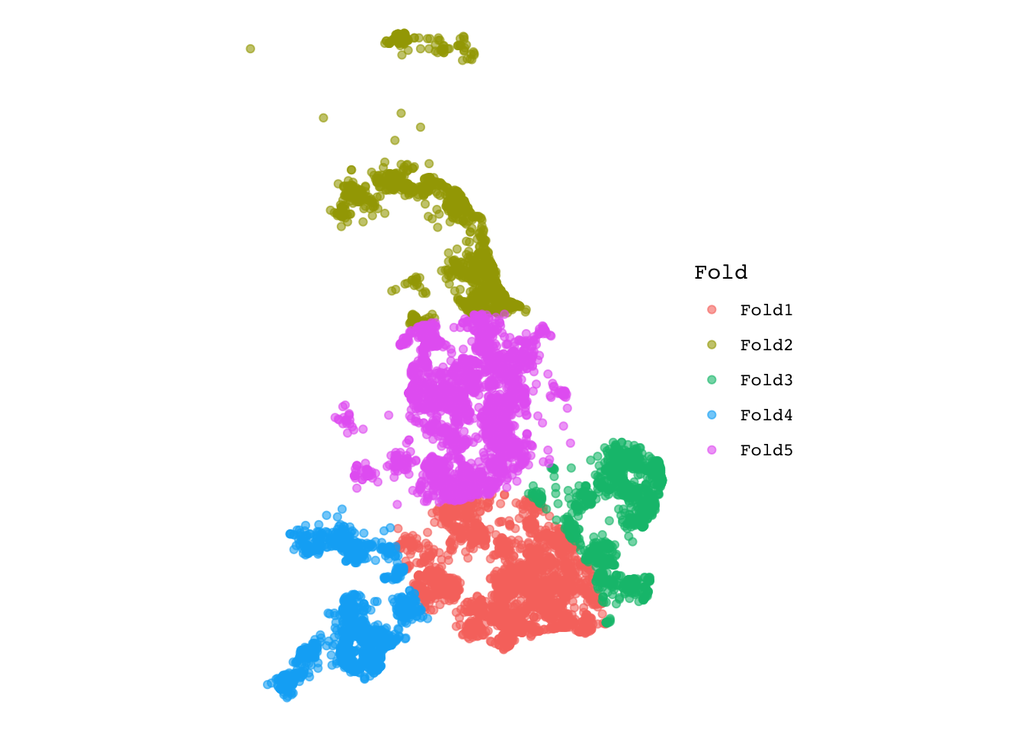

```r
load("folds_pd.rdata")
autoplot(folds)+theme_void()+theme(text = element_text(family = "mono"))
```

```r
myfolds <- list(folds$splits[[1]]$in_id,
folds$splits[[2]]$in_id,
folds$splits[[3]]$in_id,
folds$splits[[4]]$in_id,
folds$splits[[5]]$in_id)
```

## Training the model

```r
library(randomForest)
rmse <- function(a, b) {
  sqrt(mean((a - b)^2))
}
rf = randomForest(train.sub2[,-1], train.sub2$Ticks, nodesize = 5, ntree = 100, keep.inbag = TRUE)
```

Calculating the RMSE considering the 5 folds spatial cross-validation:

```r
totind <- 1:14397

rmse_rf <- 1:5
rmse_rf2 <- 1:5
for (i in 1:5) {
  cat("\nIteration number: ", i)
  indin <- myfolds[[i]]
  indout <-totind[!totind%in%indin]
  iter_rf <- randomForest(train.sub2[indin,-1], train.sub2[indin, "Ticks"], nodesize = 5, ntree = 100)
  y_hat <- predict(object = iter_rf, newdata = train.sub2[indout,])
  rmse_rf[i] <- rmse(y_hat, train.sub2[indout, "Ticks"])
  rmse_rf2[i] <- yardstick::rmse_vec("truth" = train.sub2[indout, "Ticks"], "estimate" = y_hat)
  cat("\n\nRMSE for iteration", i, ":", rmse_rf[i])
}
```

```
##
## Iteration number:  1
##
## RMSE for iteration 1 : 0.5130004
## Iteration number:  2
##
## RMSE for iteration 2 : 0.5062183
## Iteration number:  3
##
## RMSE for iteration 3 : 0.4967888
## Iteration number:  4
##
## RMSE for iteration 4 : 0.4863271
## Iteration number:  5
##
## RMSE for iteration 5 : 0.496916
```

```r
rmse_rf==rmse_rf2
```

```
## [1] TRUE TRUE TRUE TRUE TRUE
```

```r
mean(rmse_rf)
```

```
## [1] 0.4998501
```

RMSE values seem to me too low, maybe I’ve done something wrong. But I don’t know what. I have included only 11 variables in the model, the following ones (with the first one that is the y):

```r
names(train.sub2)
```

```
##  [1] "Ticks"
##  [2] "cosmonth"
##  [3] "dogs.density_aegerter.2017_m_1km_s_20160101_20181231_gb_epsg.27700_v20221201"
##  [4] "monthly.evi_mod13q1.v061._p50"
##  [5] "vis.nightlight_vcmslcfg.npp.max_m"
##  [6] "bioclim9_chelsa.v2.1_s_19820101_20101231_gb_epsg.27700_v20230207"
##  [7] "annual.evi_mod13q1.v061_p05"
##  [8] "bioclim12_chelsa.v2.1_s_19820101_20101231_gb_epsg.27700_v20230207"
##  [9] "seasonal.s1_earth.big.data.fall.vv.rmse_s_20190101_20201231_gb_epsg.27700_v20230207"
## [10] "monthf"
## [11] "seasonal.s1_earth.big.data.winter.vv.rmse_s_20190101_20201231_gb_epsg.27700_v20230207"
## [12] "bioclim8_chelsa.v2.1_s_19820101_20101231_gb_epsg.27700_v20230207"
```

I also checked in the for loop if there are problems with the cross-validations folders, and there are no overlaps in the row indexes. I also checked for the calculation of the RMSE, using the classical computation with the code and the function *rmse()* in the yardstick R package. I don’t know.

## Buliding test set

Same as before, I will just load the data with the test set

```r
test_df <- readRDS("db_hackaton_test.rds")
ids <- test_df$Grid_ID
test_df$monthf <- factor(test_df$monthf, levels = c("ago","apr","dic","feb","gen","giu","lug","mag","mar","nov","ott","set"), labels = c("Aug", "Apr", "Dec", "Feb", "Jan", "Jun", "Jul","May" ,"Mar", "Nov" ,"Oct" ,"Sep"))


names(train.sub2)%in%names(test_df)
```

```
##  [1]  TRUE  TRUE FALSE FALSE  TRUE  TRUE  TRUE  TRUE  TRUE  TRUE  TRUE  TRUE
```

```r
names(train.sub2)[3:4]
```

```
## [1] "dogs.density_aegerter.2017_m_1km_s_20160101_20181231_gb_epsg.27700_v20221201"
## [2] "monthly.evi_mod13q1.v061._p50"
```

```r
names(test_df)[14] <- names(train.sub2)[3]
names(test_df)[11] <-  names(train.sub2)[4]
names(train.sub2)%in%names(test_df)
```

```
##  [1] TRUE TRUE TRUE TRUE TRUE TRUE TRUE TRUE TRUE TRUE TRUE TRUE
```

```r
test_df <- test_df[,names(train.sub2)[-1]]


y_hat <- predict(object= rf, test_df)
y_hat <- as.data.frame(cbind(ids, y_hat))

library("writexl")
write_xlsx(y_hat,"vogliomorire.xlsx")
```